# Monitoring Success Manuscript Map

Ian Combs

09/08/2021

#### version: October 06, 2021

# About this document

#### All analyses preformed with R version 4.1.0.

# Basic setup of R environment

## Loading required packages

For the following analyses we will require the use of a number of different R packages. We can use the following code to quickly load in the packages and install any packages not previously installed in the R console.

```r
setwd("../data")

if (!require("pacman")) install.packages("pacman")
pacman::p_load("cowplot", "flextable", "ggrepel", "ggspatial", "lubridate", "officer", "paletteer", "patchwork", "rgdal", "rnaturalearth", "sf", "tidyverse", "gdata", "rgeos", "ggpubr", "readxl")
pacman::p_load_gh("eliocamp/ggnewscale")
pacman::p_load_gh("ropensci/rnaturalearthhires")
```

# Original Map

Here we are loading the Lat/Long data in from our Metadata spreadsheet that was taken from the *Outplant Summary* on the google drive. We are also loading in layers from our shapefiles in our data folder. We are changing the Lat/Long data (`sites$Lat_Y` and `sites$Long_X`) from a character class to a numeric class. And a couple of other columns to factors.

```r
sites = read_excel("../data/outplantMetadata.xlsx")
sites$General_Location <- as.factor(sites$General_Location)
sites$Site_ID <- as.factor(sites$Site_ID)
sites$Lat_Y <- as.numeric(sites$Lat_Y)
sites$Long_X <- as.numeric(sites$Long_X)


fknmsBounds <- read_sf("../data/shp/FKNMS_Boundary/FKNMS_Boundary.shp") %>% st_transform(crs = 4326)
flKeys <- read_sf("../data/shp/flKeys.shp") %>% st_transform(crs = 4326)
states = st_as_sf(ne_states(country = c("United States of America")), scale = "large")
countries = st_as_sf(ne_countries(country = c("Cuba", "Mexico", "The Bahamas"), scale = "large"))
florida = read_sf("../data/shp/flKeys.shp") %>% st_transform(crs = 4326)
bathy = read_sf("../data/shp/flBathy.shp") %>% st_transform(crs = 4326) %>% subset(subset = DATASET %in% c("fl_shelf", "fl_coast"))
tortugasBathy = read_sf("../data/shp/tortugasBathy.shp") %>% st_transform(crs = 4326)
```

Next we build a hi-res polygon of the lower kieys with the outplant sites marked. We use `ggspatial` to add a north arrow and scale bar to the main map. This was taken from the original code, once we figure out what is wrong, we will add the correct map to the larger map in the old code.

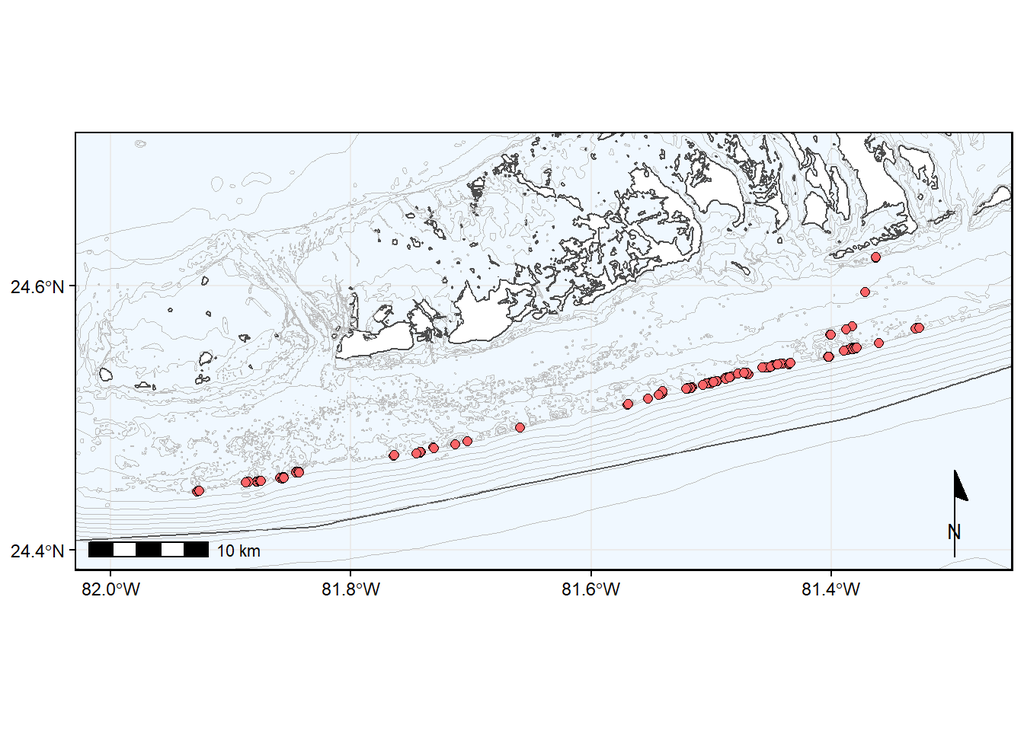

```r
mainKeys <- ggplot() +
  geom_sf(data = flKeys$geometry, fill = "white", color = "gray30") +
  geom_sf(data = fknmsBounds, fill = "black", alpha = 0.1) +
  geom_sf(data = bathy$geometry, color = "gray75", size = 0.25) +
  coord_sf(xlim = c(-81.994327, -81.284336), ylim = c(24.399133,  24.701425)) +
  geom_point(data = sites, aes(x = Long_X, y = Lat_Y), shape = 21, color = "black", fill = "#FB6467FF",size = 2) +
  annotation_scale(location = "bl") +
  annotation_north_arrow(location = "br", which_north = "true", style = north_arrow_minimal()) +
  scale_x_continuous(breaks = c(seq(-82, -80, by = .2))) +
  scale_y_continuous(breaks = c(seq(24, 25, by = .2))) +
theme_bw() +
  theme(panel.background = element_rect(fill = "aliceblue"),
        panel.border = element_rect(color = "black", size = 0.75, fill = NA),
        plot.background = element_blank(),
        axis.title = element_blank(),
        axis.ticks = element_line(color = "black"),
        axis.text = element_text(color = "black"),
        legend.position = "bottom",
        legend.direction = "vertical",
        legend.box = "horizontal",
        legend.title = element_blank())+
  rremove('legend')


mainKeys
```

# Incorporating the manuscript dataset into the map

Incorporating dataset into map and trying to figure out the discrepancies in the Lat/Long data. The outplant summary coordinates are in **red** and the manuscript dataset is in **green**. And we will keep that color scheme from here on out.

```r
testSite = read_csv("../data/FINAL_acer_data_full_07_07_2021.csv")
```

```
## * `` -> ...1
```

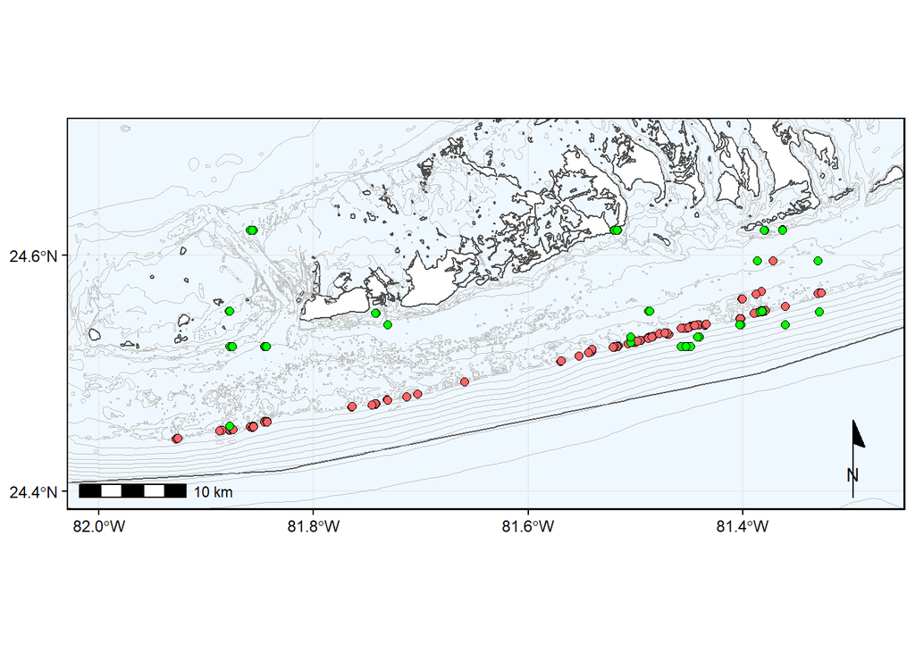

```r
testSite$site <- as.factor(testSite$site)


mainKeysComparisonTest <- ggplot() +
  geom_sf(data = flKeys$geometry, fill = "white", color = "gray30") +
  geom_sf(data = fknmsBounds, fill = "black", alpha = 0.1) +
  geom_sf(data = bathy$geometry, color = "gray75", size = 0.25) +
  coord_sf(xlim = c(-81.994327, -81.284336), ylim = c(24.399133,  24.701425)) +
  geom_point(data = sites, aes(x = Long_X, y = Lat_Y), shape = 21, color = "black", fill = "#FB6467FF",size = 2) +
  geom_point(data = testSite, aes(x = long, y = lat), shape = 21, color = 'black', fill = 'green', size = 2)+
  annotation_scale(location = "bl") +
  annotation_north_arrow(location = "br", which_north = "true", style = north_arrow_minimal()) +
  scale_x_continuous(breaks = c(seq(-82, -80, by = .2))) +
  scale_y_continuous(breaks = c(seq(24, 25, by = .2))) +
theme_bw() +
  theme(panel.background = element_rect(fill = "aliceblue"),
        panel.border = element_rect(color = "black", size = 0.75, fill = NA),
        plot.background = element_blank(),
        axis.title = element_blank(),
        axis.ticks = element_line(color = "black"),
        axis.text = element_text(color = "black"),
        legend.position = "bottom",
        legend.direction = "vertical",
        legend.box = "horizontal",
        legend.title = element_blank())+
  rremove('legend')


mainKeysComparisonTest
```

# Trying to fix the situation

Clearly the data is not the same, let’s try and take the correct lat/long data and fit it to the old dataset

```r
#Selecting the site, lat, and long data from the testSite dataset

testSiteTrunc <- testSite %>% select(site, lat, long)

# Doing the same for the sites dataset and renaming Site_ID to site so it will
# match the previous dataset
sitesTrunc <- sites %>% select(Site_ID, Lat_Y, Long_X) %>% rename(site = Site_ID)
#The sites data set has the sites delimited with underscores and the testSite
# dataset has sites delimited with hyphens, so I am finding and replacing all
# of the underscores in the sites dataset with hyphens using the function 'gsub'
sitesTrunc$site <- gsub("_","-",sitesTrunc$site)
sitesTrunc$site <- gsub("a","A", sitesTrunc$site)
sitesTrunc$site <- as.factor(sitesTrunc$site)

#Finally combining the datasets using the function full_join() within dplyr
coordFull <- full_join(testSiteTrunc, sitesTrunc, by = "site")
coordLeft <- left_join(testSiteTrunc, sitesTrunc, by = "site")
summary(latcomp <- coordFull$lat == coordFull$Lat_Y)
```

```
##    Mode   FALSE    TRUE    NA's
## logical    8669     300     127
```

```r
summary(longcomp <- coordFull$long == coordFull$Long_X)
```

```
##    Mode    TRUE    NA's
## logical    8969     127
```

```r
#Checking to see how many unique cases are in each to make sure when we
#match our new coordinates to the old, we still have the same number
#(and don't add or subtract any)
length(unique(testSiteTrunc$site))
```

```
## [1] 77
```

```r
length(unique(sitesTrunc$site))
```

```
## [1] 204
```

```r
# Trying to figure out which way to filter and join so did it both ways
repSemi <- semi_join(testSiteTrunc, sitesTrunc, by = "site")
repSemi2 <- semi_join(sitesTrunc, testSiteTrunc, by = "site")


# Now like before, checking to see which one correctly copies the right
# lat/long over to the old one
repSemi2 <- repSemi2 %>% rename(lat = Lat_Y)
repFull2 <- full_join(repSemi2, sitesTrunc, by = "site")
summary(repFull2$lat == repFull2$Lat_Y)
```

```
##    Mode    TRUE    NA's
## logical      80     127
```

```r
repFull <- full_join(repSemi, sitesTrunc, by = "site")
summary(repFull$lat == repFull$Lat_Y)
```

```
##    Mode   FALSE    TRUE    NA's
## logical    8669     300     127
```

```r
repSemi2 <- repSemi2 %>% rename(Lat_Y = lat)

# It seems repSemi2 is the correct way to join them, so now adding it to the
# truncated lat/longs from the old data set
fixedSites <- semi_join(repSemi2, testSiteTrunc, by = 'site')
length(unique(fixedSites$site))
```

```
## [1] 77
```

Now checking to see if it worked adn the coordinates are correct, going to plot it over our old map.

```r
mainKeysFixed <- ggplot() +
  geom_sf(data = flKeys$geometry, fill = "white", color = "gray30") +
  geom_sf(data = fknmsBounds, fill = "black", alpha = 0.1) +
  geom_sf(data = bathy$geometry, color = "gray75", size = 0.25) +
  coord_sf(xlim = c(-81.994327, -81.284336), ylim = c(24.399133,  24.701425)) +
  geom_point(data = sites, aes(x = Long_X, y = Lat_Y), shape = 21, color = "black", fill = "#FB6467FF",size = 2) +
  geom_point(data = fixedSites, aes(x = Long_X, y = Lat_Y), shape = 21, color = 'black', fill = 'green', size = 2)+
  annotation_scale(location = "bl") +
  annotation_north_arrow(location = "br", which_north = "true", style = north_arrow_minimal()) +
  scale_x_continuous(breaks = c(seq(-82, -80, by = .2))) +
  scale_y_continuous(breaks = c(seq(24, 25, by = .2))) +
theme_bw() +
  theme(panel.background = element_rect(fill = "aliceblue"),
        panel.border = element_rect(color = "black", size = 0.75, fill = NA),
        plot.background = element_blank(),
        axis.title = element_blank(),
        axis.ticks = element_line(color = "black"),
        axis.text = element_text(color = "black"),
        legend.position = "bottom",
        legend.direction = "vertical",
        legend.box = "horizontal",
        legend.title = element_blank())+
  rremove('legend')

mainKeysFixed
```

[output not shown]

Now we will join the fixed data set to the OG dataset.

```r
fixedData <- inner_join(repSemi2, testSite, by = 'site')


# Checking one last time to make sure I did it correctly


mainKeysFixedFull <- ggplot() +
  geom_sf(data = flKeys$geometry, fill = "white", color = "gray30") +
  geom_sf(data = fknmsBounds, fill = "black", alpha = 0.1) +
  geom_sf(data = bathy$geometry, color = "gray75", size = 0.25) +
  coord_sf(xlim = c(-81.994327, -81.284336), ylim = c(24.399133,  24.701425)) +
  geom_point(data = sites, aes(x = Long_X, y = Lat_Y), shape = 21, color = "black", fill = "#FB6467FF",size = 2) +
  geom_point(data = fixedData, aes(x = Long_X, y = Lat_Y), shape = 21, color = 'black', fill = 'green', size = 2)+
  annotation_scale(location = "bl") +
  annotation_north_arrow(location = "br", which_north = "true", style = north_arrow_minimal()) +
  scale_x_continuous(breaks = c(seq(-82, -80, by = .2))) +
  scale_y_continuous(breaks = c(seq(24, 25, by = .2))) +
theme_bw() +
  theme(panel.background = element_rect(fill = "aliceblue"),
        panel.border = element_rect(color = "black", size = 0.75, fill = NA),
        plot.background = element_blank(),
        axis.title = element_blank(),
        axis.ticks = element_line(color = "black"),
        axis.text = element_text(color = "black"),
        legend.position = "bottom",
        legend.direction = "vertical",
        legend.box = "horizontal",
        legend.title = element_blank())+
  rremove('legend')


mainKeysFixedFull
```

[output not shown]

Now I will remove the old lat/long rows and rename the dataset and save it as *FINAL_acer_data_full_07_07_2021_FIXED.csv*.

```r
finalFixedData <- fixedData %>% select(-lat,-long)

#graphing ONE MORE TIME to make sure I did it correctly

mainKeysFixedFullFinal <- ggplot() +
  geom_sf(data = flKeys$geometry, fill = "white", color = "gray30") +
  geom_sf(data = fknmsBounds, fill = "black", alpha = 0.1) +
  geom_sf(data = bathy$geometry, color = "gray75", size = 0.25) +
  coord_sf(xlim = c(-81.994327, -81.284336), ylim = c(24.399133,  24.701425)) +
  geom_point(data = sites, aes(x = Long_X, y = Lat_Y), shape = 21, color = "black", fill = "#FB6467FF",size = 2) +
  geom_point(data = finalFixedData, aes(x = Long_X, y = Lat_Y), shape = 21, color = 'black', fill = 'green', size = 2)+
  annotation_scale(location = "bl") +
  annotation_north_arrow(location = "br", which_north = "true", style = north_arrow_minimal()) +
  scale_x_continuous(breaks = c(seq(-82, -80, by = .2))) +
  scale_y_continuous(breaks = c(seq(24, 25, by = .2))) +
theme_bw() +
  theme(panel.background = element_rect(fill = "aliceblue"),
        panel.border = element_rect(color = "black", size = 0.75, fill = NA),
        plot.background = element_blank(),
        axis.title = element_blank(),
        axis.ticks = element_line(color = "black"),
        axis.text = element_text(color = "black"),
        legend.position = "bottom",
        legend.direction = "vertical",
        legend.box = "horizontal",
        legend.title = element_blank())+
  rremove('legend')

mainKeysFixedFullFinal
```

[output not shown]

```r
# Looks good!
# Saving the new dataframe

write.csv(finalFixedData, "../data/FINAL_acer_data_full_07_07_2021_FIXED.csv", row.names = FALSE)
```